# Risk Factor Analysis

## Outcome Variable

**Outcome Variable:** ever_co

## Predictor Variables

**Intervention Variable:** hdlvry

**Adjustment Set:**

unadjusted

## Stratifying Variables

The analysis was stratified on these variable(s):

- agecat
- studyid
- country

## Data Summary

| agecat | studyid | country | hdlvry | ever_co | n_cell | n |
| --- | --- | --- | --- | --- | --- | --- |
| 0-24 months | CMC-V-BCS-2002 | INDIA | 0 | 0 | 279 | 370 |
| 0-24 months | CMC-V-BCS-2002 | INDIA | 0 | 1 | 83 | 370 |
| 0-24 months | CMC-V-BCS-2002 | INDIA | 1 | 0 | 7 | 370 |
| 0-24 months | CMC-V-BCS-2002 | INDIA | 1 | 1 | 1 | 370 |
| 0-24 months | COHORTS | INDIA | 0 | 0 | 2904 | 5089 |
| 0-24 months | COHORTS | INDIA | 0 | 1 | 232 | 5089 |
| 0-24 months | COHORTS | INDIA | 1 | 0 | 1679 | 5089 |
| 0-24 months | COHORTS | INDIA | 1 | 1 | 274 | 5089 |
| 0-24 months | EE | PAKISTAN | 0 | 0 | 143 | 377 |
| 0-24 months | EE | PAKISTAN | 0 | 1 | 110 | 377 |
| 0-24 months | EE | PAKISTAN | 1 | 0 | 65 | 377 |
| 0-24 months | EE | PAKISTAN | 1 | 1 | 59 | 377 |
| 0-24 months | GMS-Nepal | NEPAL | 0 | 0 | 118 | 637 |
| 0-24 months | GMS-Nepal | NEPAL | 0 | 1 | 38 | 637 |
| 0-24 months | GMS-Nepal | NEPAL | 1 | 0 | 335 | 637 |
| 0-24 months | GMS-Nepal | NEPAL | 1 | 1 | 146 | 637 |
| 0-24 months | IRC | INDIA | 0 | 0 | 328 | 410 |
| 0-24 months | IRC | INDIA | 0 | 1 | 74 | 410 |
| 0-24 months | IRC | INDIA | 1 | 0 | 6 | 410 |
| 0-24 months | IRC | INDIA | 1 | 1 | 2 | 410 |
| 0-24 months | JiVitA-3 | BANGLADESH | 0 | 0 | 40 | 350 |
| 0-24 months | JiVitA-3 | BANGLADESH | 0 | 1 | 2 | 350 |
| 0-24 months | JiVitA-3 | BANGLADESH | 1 | 0 | 276 | 350 |
| 0-24 months | JiVitA-3 | BANGLADESH | 1 | 1 | 32 | 350 |
| 0-24 months | JiVitA-4 | BANGLADESH | 0 | 0 | 1007 | 4501 |
| 0-24 months | JiVitA-4 | BANGLADESH | 0 | 1 | 164 | 4501 |
| 0-24 months | JiVitA-4 | BANGLADESH | 1 | 0 | 2757 | 4501 |
| 0-24 months | JiVitA-4 | BANGLADESH | 1 | 1 | 573 | 4501 |
| 0-24 months | NIH-Crypto | BANGLADESH | 0 | 0 | 545 | 758 |
| 0-24 months | NIH-Crypto | BANGLADESH | 0 | 1 | 45 | 758 |

[output cut: 114 more lines]

The following strata were considered:

- agecat: 0-24 months, studyid: CMC-V-BCS-2002, country: INDIA
- agecat: 0-24 months, studyid: COHORTS, country: INDIA
- agecat: 0-24 months, studyid: EE, country: PAKISTAN
- agecat: 0-24 months, studyid: GMS-Nepal, country: NEPAL
- agecat: 0-24 months, studyid: IRC, country: INDIA
- agecat: 0-24 months, studyid: JiVitA-3, country: BANGLADESH
- agecat: 0-24 months, studyid: JiVitA-4, country: BANGLADESH
- agecat: 0-24 months, studyid: NIH-Crypto, country: BANGLADESH
- agecat: 0-24 months, studyid: PROVIDE, country: BANGLADESH
- agecat: 0-24 months, studyid: SAS-CompFeed, country: INDIA
- agecat: 0-24 months, studyid: SAS-FoodSuppl, country: INDIA
- agecat: 0-24 months, studyid: TanzaniaChild2, country: TANZANIA, UNITED REPUBLIC OF
- agecat: 0-6 months, studyid: CMC-V-BCS-2002, country: INDIA
- agecat: 0-6 months, studyid: COHORTS, country: INDIA
- agecat: 0-6 months, studyid: EE, country: PAKISTAN
- agecat: 0-6 months, studyid: GMS-Nepal, country: NEPAL
- agecat: 0-6 months, studyid: IRC, country: INDIA
- agecat: 0-6 months, studyid: JiVitA-3, country: BANGLADESH
- agecat: 0-6 months, studyid: JiVitA-4, country: BANGLADESH
- agecat: 0-6 months, studyid: NIH-Crypto, country: BANGLADESH
- agecat: 0-6 months, studyid: PROVIDE, country: BANGLADESH
- agecat: 0-6 months, studyid: SAS-CompFeed, country: INDIA
- agecat: 0-6 months, studyid: SAS-FoodSuppl, country: INDIA
- agecat: 0-6 months, studyid: TanzaniaChild2, country: TANZANIA, UNITED REPUBLIC OF
- agecat: 6-24 months, studyid: CMC-V-BCS-2002, country: INDIA
- agecat: 6-24 months, studyid: COHORTS, country: INDIA
- agecat: 6-24 months, studyid: EE, country: PAKISTAN
- agecat: 6-24 months, studyid: GMS-Nepal, country: NEPAL
- agecat: 6-24 months, studyid: IRC, country: INDIA
- agecat: 6-24 months, studyid: JiVitA-3, country: BANGLADESH
- agecat: 6-24 months, studyid: JiVitA-4, country: BANGLADESH
- agecat: 6-24 months, studyid: NIH-Crypto, country: BANGLADESH
- agecat: 6-24 months, studyid: PROVIDE, country: BANGLADESH
- agecat: 6-24 months, studyid: SAS-CompFeed, country: INDIA
- agecat: 6-24 months, studyid: SAS-FoodSuppl, country: INDIA
- agecat: 6-24 months, studyid: TanzaniaChild2, country: TANZANIA, UNITED REPUBLIC OF

### Dropped Strata

Some strata were dropped due to rare outcomes:

- agecat: 0-24 months, studyid: CMC-V-BCS-2002, country: INDIA
- agecat: 0-24 months, studyid: IRC, country: INDIA
- agecat: 0-24 months, studyid: JiVitA-3, country: BANGLADESH
- agecat: 0-24 months, studyid: TanzaniaChild2, country: TANZANIA, UNITED REPUBLIC OF
- agecat: 0-6 months, studyid: CMC-V-BCS-2002, country: INDIA
- agecat: 0-6 months, studyid: IRC, country: INDIA
- agecat: 0-6 months, studyid: JiVitA-3, country: BANGLADESH
- agecat: 0-6 months, studyid: SAS-CompFeed, country: INDIA
- agecat: 0-6 months, studyid: SAS-FoodSuppl, country: INDIA
- agecat: 0-6 months, studyid: TanzaniaChild2, country: TANZANIA, UNITED REPUBLIC OF
- agecat: 6-24 months, studyid: CMC-V-BCS-2002, country: INDIA
- agecat: 6-24 months, studyid: IRC, country: INDIA
- agecat: 6-24 months, studyid: JiVitA-3, country: BANGLADESH
- agecat: 6-24 months, studyid: TanzaniaChild2, country: TANZANIA, UNITED REPUBLIC OF

## Methods Detail

We’re interested in the causal parameters $E[Y_a]$ for all values of $a \in \mathcal{A}$. These parameters represent the mean outcome if, possibly contrary to fact, we intervened to set all units to have $A=a$. Under the randomization and positivity assumptions, these are identified by the statistical parameters $\psi_a=E_W[E_{Y|A,W}(Y|A=a,W)]$. In addition, we’re interested in the mean of $Y$, $E[Y]$ under no intervention (the observed mean). We will estimate these parameters by using SuperLearner to fit the relevant likelihood factors – $E_{Y|A,W}(Y|A=a,W)$ and $p(A=a|W)$, and then updating our likelihood fit using a joint TMLE.

For unadjusted analyses ($W=\{\}$), initial likelihoods were estimated using Lrnr_glm to estimate the simple $E(Y|A)$ and Lrnr_mean to estimate $p(A)$. For adjusted analyses, a small library containing Lrnr_glmnet, Lrnr_xgboost, and Lrnr_mean was used.

Having estimated these parameters, we will then use the delta method to estimate relative risks and attributable risks relative to a prespecified baseline level of $A$.

# Results Detail

## Results Plots

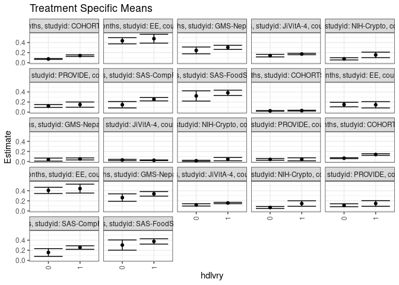

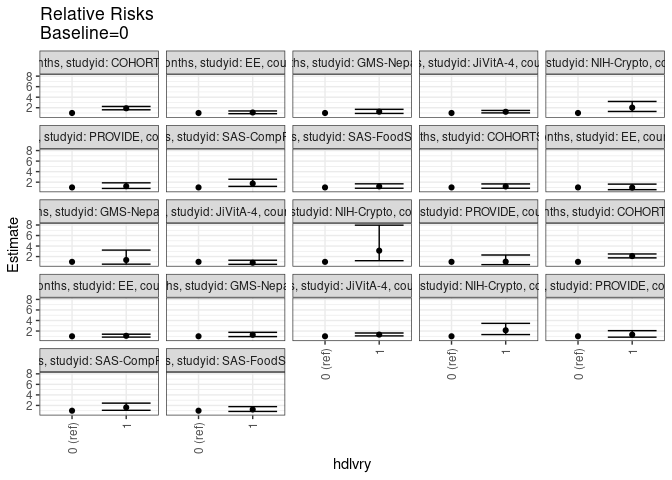

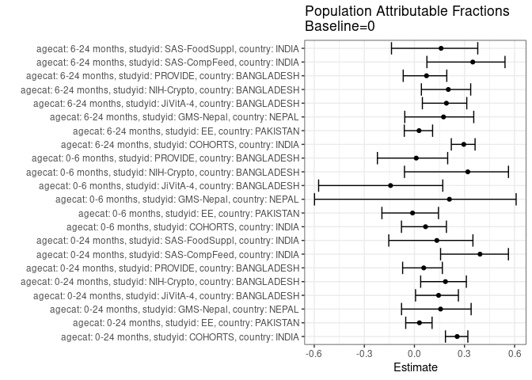

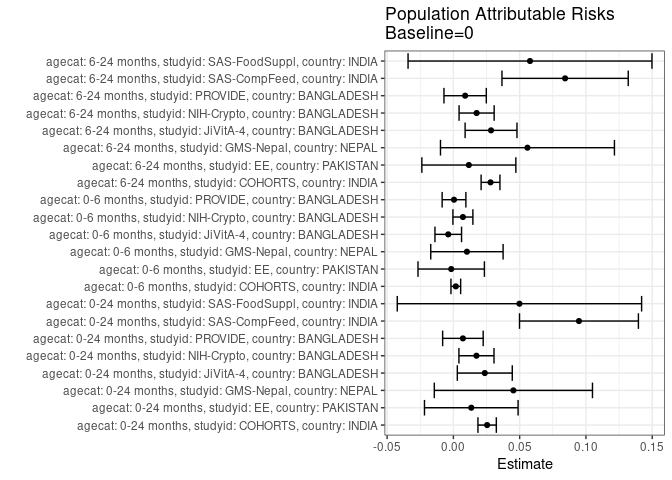

## Results Table

### Parameter: TSM

| agecat | studyid | country | intervention_level | baseline_level | estimate | ci_lower | ci_upper |
| --- | --- | --- | --- | --- | --- | --- | --- |
| 0-24 months | COHORTS | INDIA | 0 | NA | 0.0739796 | 0.0648180 | 0.0831411 |
| 0-24 months | COHORTS | INDIA | 1 | NA | 0.1402970 | 0.1248928 | 0.1557011 |
| 0-24 months | EE | PAKISTAN | 0 | NA | 0.4347826 | 0.3736168 | 0.4959484 |
| 0-24 months | EE | PAKISTAN | 1 | NA | 0.4758065 | 0.3877877 | 0.5638252 |
| 0-24 months | GMS-Nepal | NEPAL | 0 | NA | 0.2435897 | 0.1761781 | 0.3110014 |
| 0-24 months | GMS-Nepal | NEPAL | 1 | NA | 0.3035343 | 0.2624127 | 0.3446559 |
| 0-24 months | JiVitA-4 | BANGLADESH | 0 | NA | 0.1400512 | 0.1150197 | 0.1650828 |
| 0-24 months | JiVitA-4 | BANGLADESH | 1 | NA | 0.1720721 | 0.1579549 | 0.1861893 |
| 0-24 months | NIH-Crypto | BANGLADESH | 0 | NA | 0.0762712 | 0.0548393 | 0.0977031 |
| 0-24 months | NIH-Crypto | BANGLADESH | 1 | NA | 0.1547619 | 0.1000349 | 0.2094889 |
| 0-24 months | PROVIDE | BANGLADESH | 0 | NA | 0.1213873 | 0.0932709 | 0.1495037 |
| 0-24 months | PROVIDE | BANGLADESH | 1 | NA | 0.1491713 | 0.0972335 | 0.2011090 |
| 0-24 months | SAS-CompFeed | INDIA | 0 | NA | 0.1463415 | 0.0836287 | 0.2090543 |
| 0-24 months | SAS-CompFeed | INDIA | 1 | NA | 0.2556180 | 0.2226745 | 0.2885614 |
| 0-24 months | SAS-FoodSuppl | INDIA | 0 | NA | 0.3209877 | 0.2191968 | 0.4227785 |
| 0-24 months | SAS-FoodSuppl | INDIA | 1 | NA | 0.3827893 | 0.3308316 | 0.4347470 |
| 0-6 months | COHORTS | INDIA | 0 | NA | 0.0253707 | 0.0197757 | 0.0309657 |
| 0-6 months | COHORTS | INDIA | 1 | NA | 0.0300950 | 0.0223999 | 0.0377901 |
| 0-6 months | EE | PAKISTAN | 0 | NA | 0.1501976 | 0.1061163 | 0.1942790 |
| 0-6 months | EE | PAKISTAN | 1 | NA | 0.1451613 | 0.0830770 | 0.2072455 |
| 0-6 months | GMS-Nepal | NEPAL | 0 | NA | 0.0384615 | 0.0082604 | 0.0686627 |
| 0-6 months | GMS-Nepal | NEPAL | 1 | NA | 0.0519751 | 0.0321221 | 0.0718280 |
| 0-6 months | JiVitA-4 | BANGLADESH | 0 | NA | 0.0310345 | 0.0185864 | 0.0434826 |
| 0-6 months | JiVitA-4 | BANGLADESH | 1 | NA | 0.0257888 | 0.0194189 | 0.0321588 |
| 0-6 months | NIH-Crypto | BANGLADESH | 0 | NA | 0.0152542 | 0.0053581 | 0.0251504 |
| 0-6 months | NIH-Crypto | BANGLADESH | 1 | NA | 0.0476190 | 0.0153953 | 0.0798428 |
| 0-6 months | PROVIDE | BANGLADESH | 0 | NA | 0.0423892 | 0.0250433 | 0.0597351 |
| 0-6 months | PROVIDE | BANGLADESH | 1 | NA | 0.0441989 | 0.0142343 | 0.0741635 |
| 6-24 months | COHORTS | INDIA | 0 | NA | 0.0667123 | 0.0576656 | 0.0757590 |
| 6-24 months | COHORTS | INDIA | 1 | NA | 0.1397909 | 0.1238446 | 0.1557371 |
| 6-24 months | EE | PAKISTAN | 0 | NA | 0.4072581 | 0.3460262 | 0.4684899 |
| 6-24 months | EE | PAKISTAN | 1 | NA | 0.4426230 | 0.3543663 | 0.5308796 |
| 6-24 months | GMS-Nepal | NEPAL | 0 | NA | 0.2647059 | 0.1904917 | 0.3389201 |
| 6-24 months | GMS-Nepal | NEPAL | 1 | NA | 0.3389831 | 0.2932885 | 0.3846776 |
| 6-24 months | JiVitA-4 | BANGLADESH | 0 | NA | 0.1198630 | 0.0973150 | 0.1424110 |
| 6-24 months | JiVitA-4 | BANGLADESH | 1 | NA | 0.1582431 | 0.1444185 | 0.1720677 |
| 6-24 months | NIH-Crypto | BANGLADESH | 0 | NA | 0.0687831 | 0.0479372 | 0.0896290 |
| 6-24 months | NIH-Crypto | BANGLADESH | 1 | NA | 0.1472393 | 0.0928044 | 0.2016742 |
| 6-24 months | PROVIDE | BANGLADESH | 0 | NA | 0.1132898 | 0.0842708 | 0.1423087 |
| 6-24 months | PROVIDE | BANGLADESH | 1 | NA | 0.1483871 | 0.0923784 | 0.2043958 |
| 6-24 months | SAS-CompFeed | INDIA | 0 | NA | 0.1568627 | 0.0802387 | 0.2334868 |
| 6-24 months | SAS-CompFeed | INDIA | 1 | NA | 0.2543590 | 0.2196692 | 0.2890487 |
| 6-24 months | SAS-FoodSuppl | INDIA | 0 | NA | 0.3037975 | 0.2022576 | 0.4053373 |
| 6-24 months | SAS-FoodSuppl | INDIA | 1 | NA | 0.3757764 | 0.3228104 | 0.4287424 |

### Parameter: E(Y)

| agecat | studyid | country | intervention_level | baseline_level | estimate | ci_lower | ci_upper |
| --- | --- | --- | --- | --- | --- | --- | --- |
| 0-24 months | COHORTS | INDIA | NA | NA | 0.0994301 | 0.0912079 | 0.1076524 |
| 0-24 months | EE | PAKISTAN | NA | NA | 0.4482759 | 0.3980083 | 0.4985434 |
| 0-24 months | GMS-Nepal | NEPAL | NA | NA | 0.2888540 | 0.2536300 | 0.3240780 |
| 0-24 months | JiVitA-4 | BANGLADESH | NA | NA | 0.1637414 | 0.1510998 | 0.1763830 |
| 0-24 months | NIH-Crypto | BANGLADESH | NA | NA | 0.0936675 | 0.0729118 | 0.1144233 |
| 0-24 months | PROVIDE | BANGLADESH | NA | NA | 0.1285714 | 0.1037574 | 0.1533855 |
| 0-24 months | SAS-CompFeed | INDIA | NA | NA | 0.2410714 | 0.1975050 | 0.2846379 |
| 0-24 months | SAS-FoodSuppl | INDIA | NA | NA | 0.3708134 | 0.3244530 | 0.4171738 |
| 0-6 months | COHORTS | INDIA | NA | NA | 0.0271860 | 0.0226456 | 0.0317265 |
| 0-6 months | EE | PAKISTAN | NA | NA | 0.1485411 | 0.1125944 | 0.1844878 |
| 0-6 months | GMS-Nepal | NEPAL | NA | NA | 0.0486656 | 0.0319433 | 0.0653880 |
| 0-6 months | JiVitA-4 | BANGLADESH | NA | NA | 0.0271544 | 0.0212424 | 0.0330664 |
| 0-6 months | NIH-Crypto | BANGLADESH | NA | NA | 0.0224274 | 0.0118796 | 0.0329753 |
| 0-6 months | PROVIDE | BANGLADESH | NA | NA | 0.0428571 | 0.0278427 | 0.0578716 |
| 6-24 months | COHORTS | INDIA | NA | NA | 0.0947257 | 0.0863884 | 0.1030631 |
| 6-24 months | EE | PAKISTAN | NA | NA | 0.4189189 | 0.3685783 | 0.4692595 |
| 6-24 months | GMS-Nepal | NEPAL | NA | NA | 0.3205829 | 0.2815081 | 0.3596576 |
| 6-24 months | JiVitA-4 | BANGLADESH | NA | NA | 0.1482636 | 0.1364361 | 0.1600910 |
| 6-24 months | NIH-Crypto | BANGLADESH | NA | NA | 0.0863014 | 0.0659171 | 0.1066856 |
| 6-24 months | PROVIDE | BANGLADESH | NA | NA | 0.1221498 | 0.0962275 | 0.1480722 |
| 6-24 months | SAS-CompFeed | INDIA | NA | NA | 0.2411348 | 0.1953341 | 0.2869354 |
| 6-24 months | SAS-FoodSuppl | INDIA | NA | NA | 0.3615960 | 0.3145115 | 0.4086805 |

### Parameter: RR

| agecat | studyid | country | intervention_level | baseline_level | estimate | ci_lower | ci_upper |
| --- | --- | --- | --- | --- | --- | --- | --- |
| 0-24 months | COHORTS | INDIA | 0 | 0 | 1.0000000 | 1.0000000 | 1.000000 |
| 0-24 months | COHORTS | INDIA | 1 | 0 | 1.8964281 | 1.6071601 | 2.237761 |
| 0-24 months | EE | PAKISTAN | 0 | 0 | 1.0000000 | 1.0000000 | 1.000000 |
| 0-24 months | EE | PAKISTAN | 1 | 0 | 1.0943548 | 0.8674133 | 1.380671 |
| 0-24 months | GMS-Nepal | NEPAL | 0 | 0 | 1.0000000 | 1.0000000 | 1.000000 |
| 0-24 months | GMS-Nepal | NEPAL | 1 | 0 | 1.2460882 | 0.9156559 | 1.695763 |
| 0-24 months | JiVitA-4 | BANGLADESH | 0 | 0 | 1.0000000 | 1.0000000 | 1.000000 |
| 0-24 months | JiVitA-4 | BANGLADESH | 1 | 0 | 1.2286366 | 1.0138359 | 1.488947 |
| 0-24 months | NIH-Crypto | BANGLADESH | 0 | 0 | 1.0000000 | 1.0000000 | 1.000000 |
| 0-24 months | NIH-Crypto | BANGLADESH | 1 | 0 | 2.0291005 | 1.2916517 | 3.187584 |
| 0-24 months | PROVIDE | BANGLADESH | 0 | 0 | 1.0000000 | 1.0000000 | 1.000000 |
| 0-24 months | PROVIDE | BANGLADESH | 1 | 0 | 1.2288871 | 0.8089054 | 1.866922 |
| 0-24 months | SAS-CompFeed | INDIA | 0 | 0 | 1.0000000 | 1.0000000 | 1.000000 |
| 0-24 months | SAS-CompFeed | INDIA | 1 | 0 | 1.7467228 | 1.1931738 | 2.557080 |
| 0-24 months | SAS-FoodSuppl | INDIA | 0 | 0 | 1.0000000 | 1.0000000 | 1.000000 |
| 0-24 months | SAS-FoodSuppl | INDIA | 1 | 0 | 1.1925360 | 0.8446242 | 1.683757 |
| 0-6 months | COHORTS | INDIA | 0 | 0 | 1.0000000 | 1.0000000 | 1.000000 |
| 0-6 months | COHORTS | INDIA | 1 | 0 | 1.1862135 | 0.8462921 | 1.662668 |
| 0-6 months | EE | PAKISTAN | 0 | 0 | 1.0000000 | 1.0000000 | 1.000000 |
| 0-6 months | EE | PAKISTAN | 1 | 0 | 0.9664686 | 0.5753294 | 1.623525 |
| 0-6 months | GMS-Nepal | NEPAL | 0 | 0 | 1.0000000 | 1.0000000 | 1.000000 |
| 0-6 months | GMS-Nepal | NEPAL | 1 | 0 | 1.3513514 | 0.5643390 | 3.235910 |
| 0-6 months | JiVitA-4 | BANGLADESH | 0 | 0 | 1.0000000 | 1.0000000 | 1.000000 |
| 0-6 months | JiVitA-4 | BANGLADESH | 1 | 0 | 0.8309736 | 0.5270989 | 1.310033 |
| 0-6 months | NIH-Crypto | BANGLADESH | 0 | 0 | 1.0000000 | 1.0000000 | 1.000000 |
| 0-6 months | NIH-Crypto | BANGLADESH | 1 | 0 | 3.1216931 | 1.2225460 | 7.971044 |
| 0-6 months | PROVIDE | BANGLADESH | 0 | 0 | 1.0000000 | 1.0000000 | 1.000000 |
| 0-6 months | PROVIDE | BANGLADESH | 1 | 0 | 1.0426921 | 0.4723343 | 2.301774 |
| 6-24 months | COHORTS | INDIA | 0 | 0 | 1.0000000 | 1.0000000 | 1.000000 |
| 6-24 months | COHORTS | INDIA | 1 | 0 | 2.0954292 | 1.7551471 | 2.501684 |
| 6-24 months | EE | PAKISTAN | 0 | 0 | 1.0000000 | 1.0000000 | 1.000000 |
| 6-24 months | EE | PAKISTAN | 1 | 0 | 1.0868366 | 0.8466599 | 1.395145 |
| 6-24 months | GMS-Nepal | NEPAL | 0 | 0 | 1.0000000 | 1.0000000 | 1.000000 |
| 6-24 months | GMS-Nepal | NEPAL | 1 | 0 | 1.2806026 | 0.9382338 | 1.747905 |
| 6-24 months | JiVitA-4 | BANGLADESH | 0 | 0 | 1.0000000 | 1.0000000 | 1.000000 |
| 6-24 months | JiVitA-4 | BANGLADESH | 1 | 0 | 1.3201994 | 1.0732071 | 1.624036 |
| 6-24 months | NIH-Crypto | BANGLADESH | 0 | 0 | 1.0000000 | 1.0000000 | 1.000000 |
| 6-24 months | NIH-Crypto | BANGLADESH | 1 | 0 | 2.1406324 | 1.3271750 | 3.452677 |
| 6-24 months | PROVIDE | BANGLADESH | 0 | 0 | 1.0000000 | 1.0000000 | 1.000000 |
| 6-24 months | PROVIDE | BANGLADESH | 1 | 0 | 1.3098015 | 0.8300390 | 2.066867 |
| 6-24 months | SAS-CompFeed | INDIA | 0 | 0 | 1.0000000 | 1.0000000 | 1.000000 |
| 6-24 months | SAS-CompFeed | INDIA | 1 | 0 | 1.6215385 | 1.0780601 | 2.438998 |
| 6-24 months | SAS-FoodSuppl | INDIA | 0 | 0 | 1.0000000 | 1.0000000 | 1.000000 |
| 6-24 months | SAS-FoodSuppl | INDIA | 1 | 0 | 1.2369306 | 0.8606157 | 1.777794 |

### Parameter: PAR

| agecat | studyid | country | intervention_level | baseline_level | estimate | ci_lower | ci_upper |
| --- | --- | --- | --- | --- | --- | --- | --- |
| 0-24 months | COHORTS | INDIA | 0 | NA | 0.0254506 | 0.0185155 | 0.0323856 |
| 0-24 months | EE | PAKISTAN | 0 | NA | 0.0134933 | -0.0218149 | 0.0488014 |
| 0-24 months | GMS-Nepal | NEPAL | 0 | NA | 0.0452643 | -0.0143953 | 0.1049238 |
| 0-24 months | JiVitA-4 | BANGLADESH | 0 | NA | 0.0236902 | 0.0029616 | 0.0444187 |
| 0-24 months | NIH-Crypto | BANGLADESH | 0 | NA | 0.0173964 | 0.0041646 | 0.0306282 |
| 0-24 months | PROVIDE | BANGLADESH | 0 | NA | 0.0071841 | -0.0081136 | 0.0224819 |
| 0-24 months | SAS-CompFeed | INDIA | 0 | NA | 0.0947300 | 0.0498795 | 0.1395804 |
| 0-24 months | SAS-FoodSuppl | INDIA | 0 | NA | 0.0498257 | -0.0423426 | 0.1419941 |
| 0-6 months | COHORTS | INDIA | 0 | NA | 0.0018154 | -0.0018411 | 0.0054718 |
| 0-6 months | EE | PAKISTAN | 0 | NA | -0.0016565 | -0.0267017 | 0.0233887 |
| 0-6 months | GMS-Nepal | NEPAL | 0 | NA | 0.0102041 | -0.0170906 | 0.0374988 |
| 0-6 months | JiVitA-4 | BANGLADESH | 0 | NA | -0.0038801 | -0.0139095 | 0.0061494 |
| 0-6 months | NIH-Crypto | BANGLADESH | 0 | NA | 0.0071732 | -0.0003591 | 0.0147055 |
| 0-6 months | PROVIDE | BANGLADESH | 0 | NA | 0.0004679 | -0.0084848 | 0.0094207 |
| 6-24 months | COHORTS | INDIA | 0 | NA | 0.0280135 | 0.0209131 | 0.0351138 |
| 6-24 months | EE | PAKISTAN | 0 | NA | 0.0116609 | -0.0237986 | 0.0471203 |
| 6-24 months | GMS-Nepal | NEPAL | 0 | NA | 0.0558770 | -0.0097415 | 0.1214955 |
| 6-24 months | JiVitA-4 | BANGLADESH | 0 | NA | 0.0284006 | 0.0088375 | 0.0479636 |
| 6-24 months | NIH-Crypto | BANGLADESH | 0 | NA | 0.0175183 | 0.0042886 | 0.0307480 |
| 6-24 months | PROVIDE | BANGLADESH | 0 | NA | 0.0088601 | -0.0071097 | 0.0248298 |
| 6-24 months | SAS-CompFeed | INDIA | 0 | NA | 0.0842720 | 0.0366358 | 0.1319082 |
| 6-24 months | SAS-FoodSuppl | INDIA | 0 | NA | 0.0577985 | -0.0342061 | 0.1498032 |

### Parameter: PAF

| agecat | studyid | country | intervention_level | baseline_level | estimate | ci_lower | ci_upper |
| --- | --- | --- | --- | --- | --- | --- | --- |
| 0-24 months | COHORTS | INDIA | 0 | NA | 0.2559641 | 0.1858442 | 0.3200449 |
| 0-24 months | EE | PAKISTAN | 0 | NA | 0.0301003 | -0.0519957 | 0.1057897 |
| 0-24 months | GMS-Nepal | NEPAL | 0 | NA | 0.1567029 | -0.0769704 | 0.3396755 |
| 0-24 months | JiVitA-4 | BANGLADESH | 0 | NA | 0.1446803 | 0.0067571 | 0.2634512 |
| 0-24 months | NIH-Crypto | BANGLADESH | 0 | NA | 0.1857245 | 0.0374873 | 0.3111316 |
| 0-24 months | PROVIDE | BANGLADESH | 0 | NA | 0.0558767 | -0.0705282 | 0.1673560 |
| 0-24 months | SAS-CompFeed | INDIA | 0 | NA | 0.3929539 | 0.1567179 | 0.5630111 |
| 0-24 months | SAS-FoodSuppl | INDIA | 0 | NA | 0.1343688 | -0.1535649 | 0.3504332 |
| 0-6 months | COHORTS | INDIA | 0 | NA | 0.0667757 | -0.0773884 | 0.1916493 |
| 0-6 months | EE | PAKISTAN | 0 | NA | -0.0111519 | -0.1946161 | 0.1441366 |
| 0-6 months | GMS-Nepal | NEPAL | 0 | NA | 0.2096774 | -0.5983068 | 0.6092053 |
| 0-6 months | JiVitA-4 | BANGLADESH | 0 | NA | -0.1428897 | -0.5736608 | 0.1699629 |
| 0-6 months | NIH-Crypto | BANGLADESH | 0 | NA | 0.3198405 | -0.0594838 | 0.5633562 |
| 0-6 months | PROVIDE | BANGLADESH | 0 | NA | 0.0109184 | -0.2216378 | 0.1992043 |
| 6-24 months | COHORTS | INDIA | 0 | NA | 0.2957323 | 0.2210309 | 0.3632699 |
| 6-24 months | EE | PAKISTAN | 0 | NA | 0.0278356 | -0.0606328 | 0.1089247 |
| 6-24 months | GMS-Nepal | NEPAL | 0 | NA | 0.1742981 | -0.0576777 | 0.3553957 |
| 6-24 months | JiVitA-4 | BANGLADESH | 0 | NA | 0.1915546 | 0.0477393 | 0.3136501 |
| 6-24 months | NIH-Crypto | BANGLADESH | 0 | NA | 0.2029898 | 0.0418128 | 0.3370552 |
| 6-24 months | PROVIDE | BANGLADESH | 0 | NA | 0.0725345 | -0.0670922 | 0.1938913 |
| 6-24 months | SAS-CompFeed | INDIA | 0 | NA | 0.3494810 | 0.0748944 | 0.5425657 |
| 6-24 months | SAS-FoodSuppl | INDIA | 0 | NA | 0.1598429 | -0.1372733 | 0.3793365 |